# Ford_go_bike

## by Ahmed_Adel_Hekal

> - Ford Gobike dataset is dataset for Ford bike sharing project .
> - This data contains 16 feature that record every thing  
>   from location ,station id ,station name ,longitude and latitude to end station ,end_station_id ,end_station_name ..etc .

# Our data is 183412 entries with 16 feature . we notice that we have missing data

```
<class 'pandas.core.frame.DataFrame'>
RangeIndex: 183412 entries, 0 to 183411
Data columns (total 16 columns):
 #   Column                   Non-Null Count   Dtype
---  ------                   --------------   -----
 0   duration_sec             183412 non-null  int64
 1   start_time               183412 non-null  object
 2   end_time                 183412 non-null  object
 3   start_station_id         183215 non-null  float64
 4   start_station_name       183215 non-null  object
 5   start_station_latitude   183412 non-null  float64
 6   start_station_longitude  183412 non-null  float64
 7   end_station_id           183215 non-null  float64
 8   end_station_name         183215 non-null  object
 9   end_station_latitude     183412 non-null  float64
 10  end_station_longitude    183412 non-null  float64
 11  bike_id                  183412 non-null  int64
 12  user_type                183412 non-null  object
 13  member_birth_year        175147 non-null  float64
 14  member_gender            175147 non-null  object
 15  bike_share_for_all_trip  183412 non-null  object
dtypes: float64(7), int64(2), object(7)
memory usage: 22.4+ MB
```

### After cleaning my new dataset is :.

> My dataset is 183412 entries ,16 columns .after clean it up the new dataset is 174952 entries ,12 columns

### my main features of interest are :.

> - member_gender ,user_type ,member_birth_year ,start_station_name ,end_station_name

### Questions I am try to answer :.

> - who is more likely to use the service (customer or subscriber) ?
> - Which gender is more likely to ride a bike ?
> - which station is more frequent to start the trip from and which is for end of the trip ?
> - Is there is a relation between age & gender ?

### Features in the dataset that will be used to support me :.

> - member_gender ,user_type ,member_birth_year ,start_station_name ,end_station_name

### Now i will divide my dataset to customers & subscribers datasets to study each seperately

### plot customer dataset based on gender

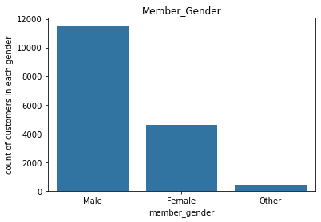

# we see most of our users are males

### Before ploting age variable try to detect outliers and remove it

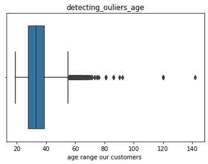

## Age range from 20 to 50 year with most of our data is between 27 & 37

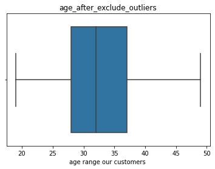

## Now we plot age to see most frequent age

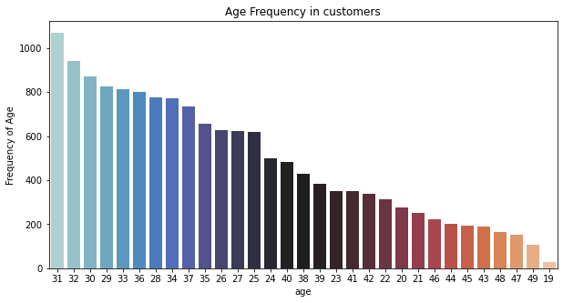